# Modello di riconoscimento per linguaggio AI-like

Cesarino P., Colapinto G., Quadrelli E.

2026-04-20

**INTRODUZIONE**

Il presente elaborato ha lo scopo di individuare, se presenti, differenze stilistiche e strutturali tra il linguaggio umano e quello delle intelligenze artificiali mediante l’utilizzo di modelli statistici. Successivamente, i modelli che sono risultati più robusti in fase di testing verranno applicati a un dataset di *abstract* di articoli scientifici, al fine di valutare l’evoluzione del linguaggio nel tempo. Si sottolinea che questa ricerca non si propone di valutare la presenza o l’utilizzo di strumenti di intelligenza artificiale (IA), ma unicamente di verificare la somiglianza dei testi reali con quelli che i modelli, in fase di training, riconoscono come generati dall’IA; per questo motivo si parla di scrittura *AI-like*, intesa come caratterizzata da elementi tipici del linguaggio delle IA.

**DATASET E PRE-PROCESSING**

Sono stati utilizzati due dataset in fase di costruzione e selezione del modello e un terzo per rispondere alla domanda di ricerca, tutti reperiti su *kaggle.com*. Il primo (“NYT AI Generated vs. Human text”), contenente 7321 testi scritti sia con linguaggio umano, sia utilizzando diverse IA, è stato utilizzato per il training e il primo test. Il secondo (“LLM - Detect AI Generated Text Dataset”), composto da diversi saggi etichettati come umani o IA, è stato utilizzato per un ulteriore test riguardo la capacità di generalizzazione dei modelli costruiti. Il terzo (“arXiv_scientific dataset”) contiene circa 136000 *abstract* di articoli scientifici riguardanti temi differenti con la relativa data di pubblicazione. Data l’attendibilità della fonte, i dataset sono risultati pressoché privi di valori mancanti.

Verrà mostrata solo la fase di pre-processing riguardante il primo dataset, essendo simile anche per gli altri due.

Il dataset “NYT AI Generated vs. Human text” è composto da 7321 osservazioni, ciascuna contenente un testo umano e le sue relative rielaborazioni da parte di 7 IA. Il dataset di lavoro è realizzato unendo tutti i testi umani e i testi provenienti da 3 delle 7 IA in modo bilanciato, così da ottenere un nuovo dataset con lo stesso numero di testi umani e di testi IA. Le IA esaminate sono *GPT_4-o*, *LLaMA-8B* e *Gemma-2-9b*. Il training set è composto dal 70% delle osservazioni del dataset di lavoro e il test set dal restante 30%.

Per trattare dati non strutturati è necessario trasformarli in una matrice di dati compatibile con gli algoritmi di classificazione. In particolare:

- costruzione e pulizia del corpus (stemming, rimozione spazi bianchi, trasformazione lettere maiuscole in minuscole);

```r
corpus <- Corpus(VectorSource(training$testo))
corpus
```

```
## <<SimpleCorpus>>
## Metadata:  corpus specific: 1, document level (indexed): 0
## Content:  documents: 10157
```

```r
corpus <- tm_map(corpus,stemDocument)
corpus <- tm_map(corpus,stripWhitespace)
corpus <- tm_map(corpus,content_transformer(tolower))
```

- creazione di unigrammi e bigrammi;

```r
tokens <- tokens(corpus(corpus),
                 remove_punct = T,
                 remove_numbers = T )
ngrams <- tokens_ngrams(tokens, n = 1:2)
```

- costruzione TF-IDF e rimozione di alcuni termini possibilmente critici;

```r
dfm <- dfm_trim(dfm(ngrams),min_termfreq=1000)
dfm <- dfm_remove(dfm,
                  pattern = c("site*", "*site",
                              "search*", "*search",
                              "navig*", "*navig",
                              "mobil*", "*mobil"),
                  valuetype = "glob")

dfm_tf_idf <- dfm_tfidf(dfm)
```

- inserimento di features specifiche per la differenziazione dei linguaggi.

```r
features <- data.frame(testo = training$testo) %>%
  mutate(
    n_parole = count_words(testo),
    n_frasi = count_sentences(testo),
    l_frase = n_parole / n_frasi,
    punteggiatura = str_count(testo,"[.,;:!?]"),
    stopwords = ntoken(tokens_select(tokens,
                                     pattern = stopwords("en"))),
    uniche = rowSums(dfm == 1)
  )
```

La scelta di non rimuovere le stopwords è data dal loro utilizzo nei bigrammi che può contribuire alla differenziazione dei linguaggi. I grafici presentati riguardano le distribuzioni di alcune delle features analizzate.

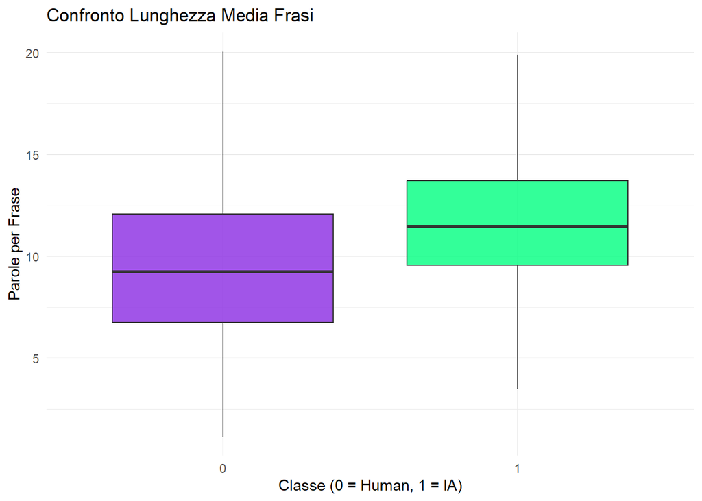

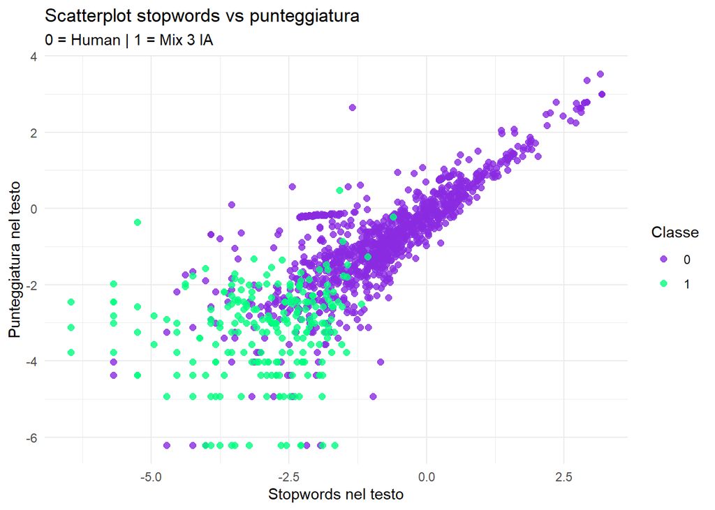

Successivamente viene costruita una matrice unendo tf-idf e features (X), sulla quale vengono calcolate le componenti principali per ridurne le dimensioni. Vengono poi selezionate le k componenti principali con varianza spiegata superiore al 70%.

```r
pc <- prcomp(X, scale. = T, center = T)
varianza_spiegata <- cumsum(pc$sdev^2 / sum(pc$sdev^2))
k <- which(varianza_spiegata > 0.7)[1]
X_pca <- pc$x[, 1:k]
```

Dal grafico sottostante si può notare come, da un’analisi preliminare delle prime due componenti principali, il linguaggio delle IA risulti più standardizzato di quello umano, evidentemente più variabile.

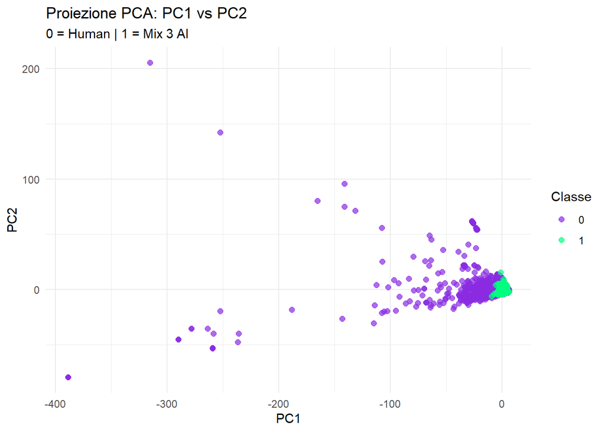

Nello specifico, si può vedere che la prima componente principale contiene le variabili inserite precedentemente e alcune stopwords, mentre la seconda componente principale è composta da parole relative alla politica, un argomento molto frequente nel dataset. Il fatto che la seconda componente sia così specializzata su una tematica potrebbe causare problemi nella generalizzazione dei modelli, in quanto parte della variabilità spiegata è legata al contenuto specifico dei testi.

Principali variabili per le prime due componenti

| PC1 | PC2 |
| --- | --- |
| stopwords | state |
| n_parole | senate |
| to | senat_race |
| and | race |
| a | poll_close |
| of | estim |
| the | eastern |
| that | vote |
| but | to_win |
| punteggiatura | governor |

**COSTRUZIONE DEI MODELLI E TEST**

I primi modelli costruiti per verificare se e come si potessero dividere le due classi, Umano e IA, sono stati **LDA** (Linear Discriminant Analysis) e **QDA** (Quadratic Discriminant Analysis). Entrambi i modelli assumono la normalità dei dati, ma la differenza che spicca tra i due è nella struttura delle covarianze: il primo modello assume le matrici di varianze e covarianze uguali per tutte le osservazioni, il secondo le assume invece diverse. LDA in spazi di alta dimensionalità come quello in esame risulta comunque un classificatore robusto.

```r
lda = lda(label ~ ., data = X_pca_labels)
pred <- predict(lda, as.data.frame(X_test_pca))

qda = qda(label ~ ., data = X_pca_labels)
pred_qda = predict(qda, as.data.frame(X_test_pca))
```

Questo si riflette nella creazione di “linee di confine” che sono rispettivamente lineari e non lineari.

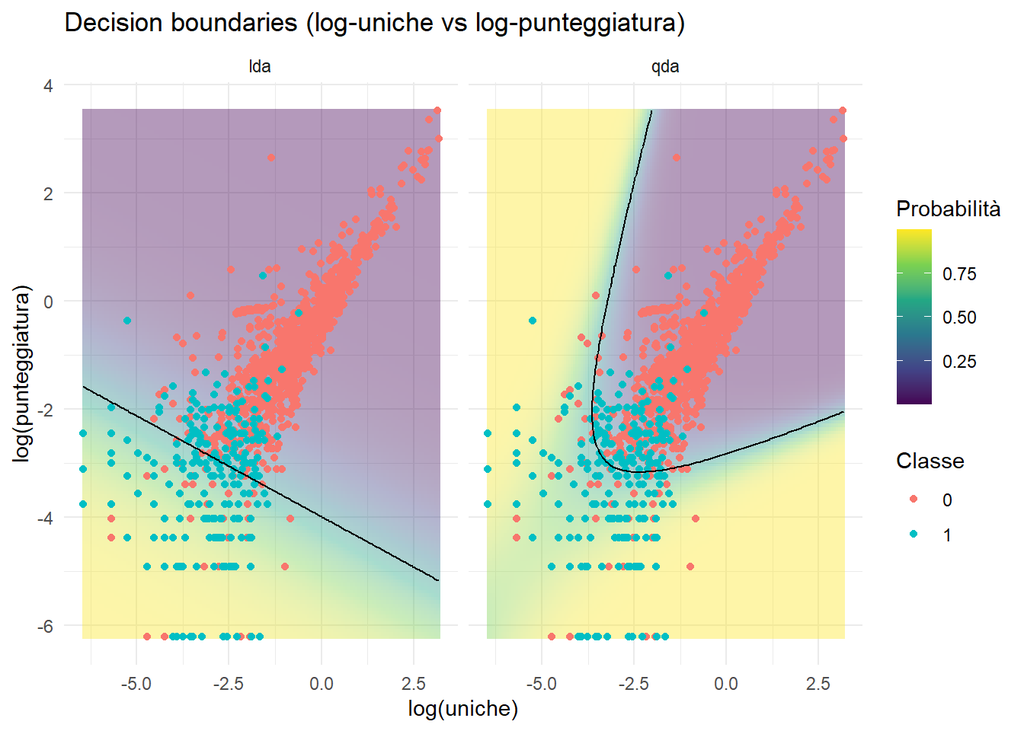

Un ulteriore modello, tra i più usati e conosciuti, spesso usato come confronto con l’LDA, è la **regressione logistica**. Tipicamente la regressione logistica ottiene dei risultati migliori anche se le assunzioni di normalità non sono verificate, risultando più flessibile di LDA.

```r
# LOGISTICA ---------------------------------------------------------------
m1 <- glm(as.factor(label) ~ ., data = X_pca_labels, family=binomial)

pred_logi <- predict(m1, as.data.frame(X_test_pca), type="response")
pred_class <- ifelse(pred_logi  > 0.5, "1", "0")
```

Per quanto riguarda invece il modello **K-NN** (K nearest neighbors), il dataset è stato diviso in maniera differente: il test racchiude sempre il 30% delle osservazioni, mentre le rimanenti sono state divise tra training e validation set. Quest’ultimo è fondamentale per la selezione del parametro k ottimale. Il modello K-NN è molto efficace nei contesti in cui le linee di confine sono altamente non lineari, tuttavia in spazi con dimensionalità così elevata potrebbe non essere il metodo migliore. Il parametro k è stato posto uguale a 6, escludendo i valori 1 e 2 per evitare overfitting.

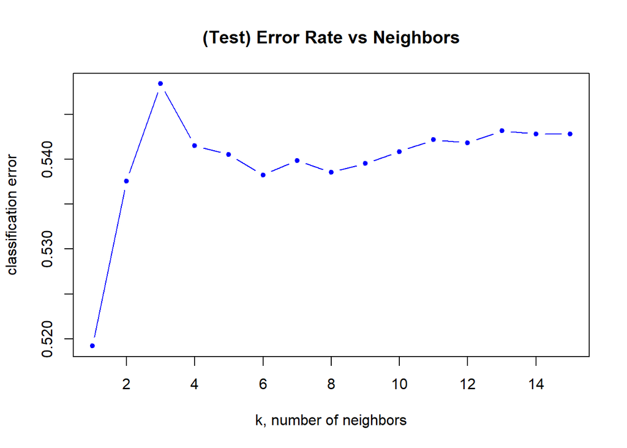

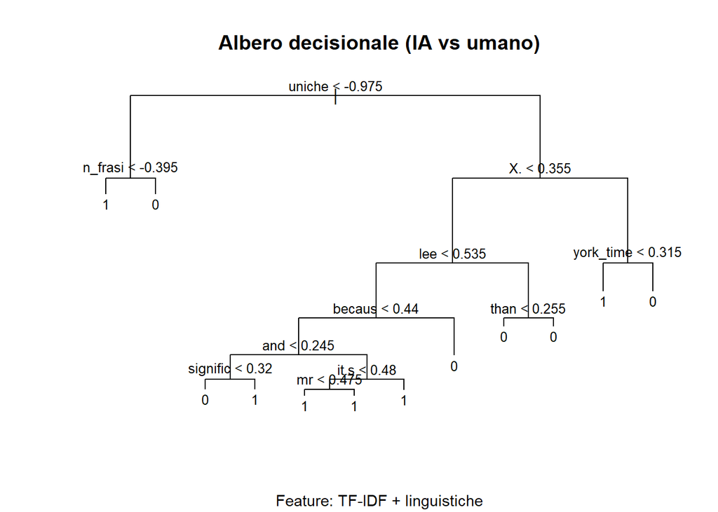

Per accertare la possibilità dei modelli creati di generalizzare il problema, è stato successivamente eseguito un ulteriore test sul secondo dataset, completamente indipendente dal primo. Questi sono i risultati ottenuti:

Confronto performance modelli (Test 1 vs Test 2)

| Modello | test1 | test2 | delta |
| --- | --- | --- | --- |
| Logistica | 0.9830 | 0.9260 | -0.0570 |
| K-NN | 0.9614 | 0.9286 | -0.0328 |
| LDA | 0.9603 | 0.9374 | -0.0229 |
| Alberi decisionali | 0.8539 | 0.7954 | -0.0585 |
| QDA | 0.7218 | 0.3096 | -0.4122 |

**APPLICAZIONE**

I modelli selezionati vengono utilizzati per un’analisi dell’evoluzione del linguaggio negli *abstract* di articoli scientifici. A partire dal dataset “arXiv_scientific dataset” si esegue la procedura di *pre-processing* già presentata considerando due variabili: data di pubblicazione, selezionando solo le osservazioni successive al 01/01/2008, e testo dell’*abstract* (chiamato *summary* nel dataset originale), su cui vengono applicati i modelli. I modelli scelti per l’applicazione sono **K-NN** (K = 6), **LDA** e **regressione logistica**.

```r
#LDA
pred_papers <- predict(lda, as.data.frame(X_papers_pca))

#Logistica
pred_logi <- predict(m1, as.data.frame(X_papers_pca), type="response")
pred_class <- ifelse(pred_logi  > 0.5, "1", "0") #Logistica

#K-NN (K=6)
pred_k <- knn(train = X_pca, test = X_papers_pca, cl = training$label, k = 6)
```

Per ovviare alla variabilità del numero di articoli disponibili nei vari anni, i dati sono considerati come percentuale di testi risultati *AI-like* sul totale dei testi disponibili per ogni anno.

Le differenze nelle stime di classificazione che si osservano nel grafico sottostante sono dovute alla diversa natura dei classificatori: la scelta della soglia fissa pari a *0.5* per la regressione logistica potrebbe spiegare la maggiore sensibilità del modello.

Percentuale di testi classificati come AI-like per anno e modello

| Anno | Logistica | LDA | KNN |
| --- | --- | --- | --- |
| 2009 | 0.426 | 0.059 | 0.059 |
| 2010 | 0.458 | 0.112 | 0.047 |
| 2011 | 0.388 | 0.104 | 0.040 |
| 2012 | 0.397 | 0.056 | 0.015 |
| 2013 | 0.423 | 0.085 | 0.052 |
| 2014 | 0.436 | 0.078 | 0.036 |
| 2015 | 0.464 | 0.079 | 0.043 |
| 2016 | 0.476 | 0.109 | 0.049 |
| 2017 | 0.502 | 0.101 | 0.050 |
| 2018 | 0.471 | 0.089 | 0.043 |
| 2019 | 0.494 | 0.089 | 0.053 |
| 2020 | 0.508 | 0.101 | 0.050 |
| 2021 | 0.533 | 0.113 | 0.063 |
| 2022 | 0.528 | 0.115 | 0.061 |
| 2023 | 0.603 | 0.170 | 0.092 |
| 2024 | 0.688 | 0.246 | 0.105 |
| 2025 | 0.669 | 0.281 | 0.173 |

Tutti i modelli evidenziano però un aumento nel tempo dello stile *AI-like* nei testi, con un particolare incremento dal 2022 in poi nonostante le differenti stime di classificazione ottenute.

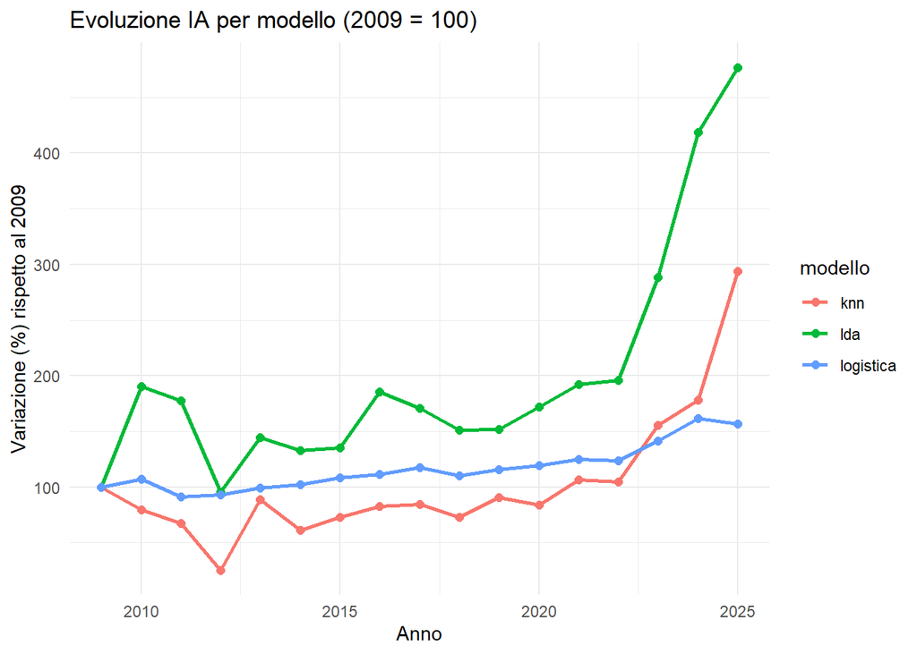

Analizzando il periodo dal 2022 in poi con un livello di dettaglio mensile emerge un trend positivo con tutti i modelli, con andamento più stabile per quanto riguarda il modello di regressione logistica e più variabile con K-NN e LDA.

La maggiore variabilità di questi ultimi è riconducibile a una minore presenza percentuale rilevata inizialmente che comporta incrementi relativi più evidenti.

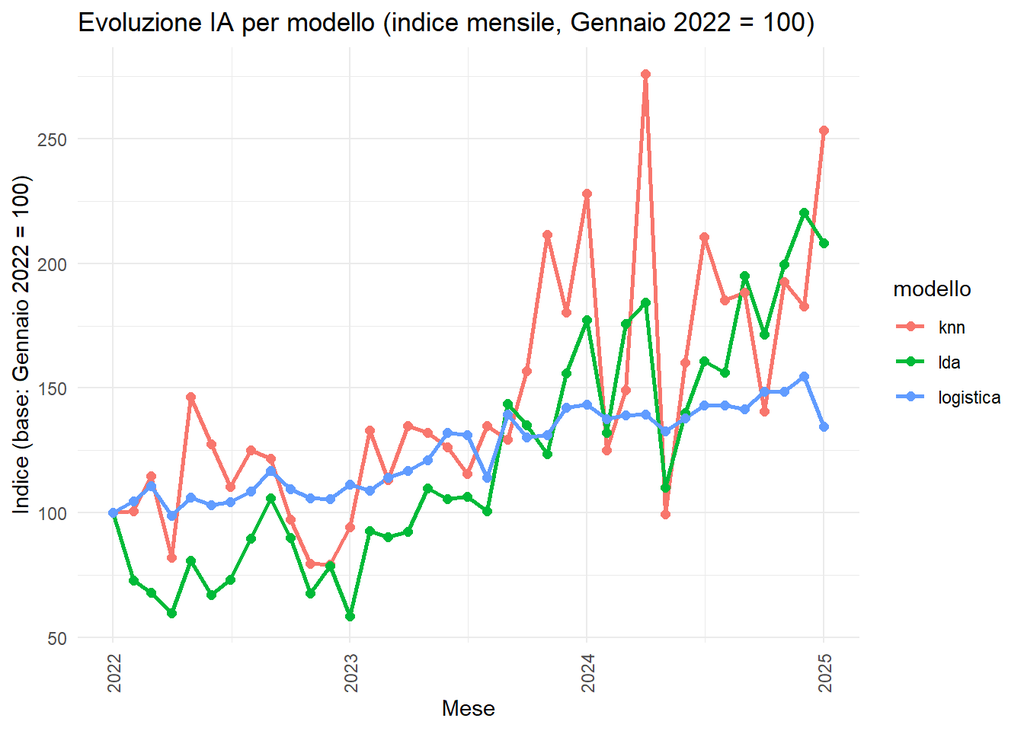

**CONCLUSIONI**

Questo progetto mostra come sia possibile distinguere la scrittura umana da quella dell’intelligenza artificiale utilizzando unigrammi, bigrammi e alcune caratteristiche stilistiche come punteggiatura, lunghezza media delle frasi e stopwords.

In particolare, i modelli lineari, LDA e logistica, si sono rivelati tra i migliori per quanto riguarda la generalizzazione, soprattutto perché risentono poco del problema della dimensionalità; l’opposto è accaduto per il modello che meno è riuscito ad adattarsi al cambio di dataset, QDA, per il quale la dimensionalità elevata è un problema. K-NN, nonostante la scelta del parametro k=6, ha dato degli ottimi risultati sia nel test interno, che nel test esterno. Gli alberi decisionali, infine, sono più uno strumento esplorativo che realmente previsivo, quindi ci si aspettava dei risultati simili a quelli ottenuti.

Tale andamento può essere riconducibile alla diffusione delle intelligenze artificiali commerciali e alla loro progressiva adozione nei processi quotidiani. È tuttavia importante sottolineare, come specificato inizialmente, che il modello non rileva l’utilizzo di intelligenza artificiale, bensì intercetta pattern linguistici comuni tra i testi generati dall’IA, come la minore variabilità sintattica e lessicale, la maggiore standardizzazione e l’uso frequente di determinate strutture. In quest’ottica, la crescita moderata pre-2022 può essere riconducibile a un processo di standardizzazione del linguaggio utilizzato negli abstract delle pubblicazioni scientifiche, che può anche dar luogo a falsi positivi. In sintesi, i risultati ottenuti sono compatibili con: - la presenza di un processo di standardizzazione costante degli *abstract* delle pubblicazioni scientifiche, caratterizzati da pattern lessicali e sintattici sempre più comuni tra loro; - un possibile utilizzo di strumenti IA a partire dal 2022, riflesso nello stile di scrittura.

Da questa analisi di carattere puramente statistico non è possibile trarre conclusioni di causalità, ma solo di correlazione temporale.

Infine, si specifica che i modelli proposti sono costruiti su dataset di testi generali volti a intercettare pattern linguistici generici. Un’analisi più approfondita richiederebbe modelli costruiti su dataset di training con argomento affine a quello di analisi, con lessico e strutture caratteristiche delle pubblicazioni scientifiche.